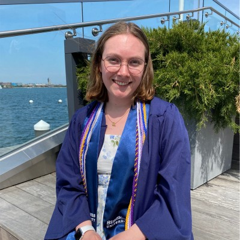

# Megan Willis

## Bio

I graduated from Simmons University with my B.S. in Data Science and Analytics, in May, 2022. I am currently attending Boston University to receive my M.S. in Biostatistics, expected to graduate this December (2023). I have experience using R and Python for Data Science and Statistical Programming.

## Education

**Boston University** | Boston, MA

*M.S. in Biostatistics*, Anticipated December 2023

*GPA:* 3.39

**Simmons University** | Boston, MA

*B.S. in Data Science & Analytics*, May 2022

*Minor:* Mathematics, Biostatistics, Computer Science

*GPA:* 3.84

## Experience

**Vertex Pharmaceuticals**, Boston MA  
*Statistical Programming Extern*, 2022-Present

In my current position as a Statistical Programming Extern, I have worked to create multiple interactive dashboards to better visualize Clinical Trial data. After preparing the complex data to best be used in the dashboards, I use ggplot2 to make the initial plots, RShiny to host the plots as a dashboard, and Plotly to add interactive features to make the plots easily readable.

**Simmons University**, Boston, MA | **Princeton University**, Princeton, NJ  
*Research Assistant*, 2021-2022

As an RA, I spent time labeling speech data using linguistics software (Praat), I worked on writing an algorithm that extracted pitch measurements from the labeled data within a given time interval, and used neural networks in R to investigate different speech patterns.

**Simmons University**, Boston MA  
*Teaching Assistant*, 2020-2021

During my time as a teaching assistant, I aided professors during class and lab times by helping answer students questions, and by grading assignments. I also occasionally held office hours to meet with students outside of regular course meetings. I worked as a TA across multiple disciplines, including the courses: Database Management Systems, Intro to Computer Science, Probability, Linear Algebra, and Calculus II.

## Resume

To view my Resume, click here

### Coursework (Boston University)

- Intermediate Statistical Programming (in SAS)
- Epidemiology
- Probability
- Mathematical Statistics
- Linear Models
- Applied Statistics for Clinical Trials
- Statistical Methods in Epidemiology
- Bayesian Models

### Relevant Coursework (Simmons University)

- Data Science
- Statistical Design & Analysis
- Intro to Computer Science
- Regression
- Advanced Linear Algebra
- Probability
- Statistical Theory
- Multivariable Calculus
- Discrete Math
- Database Management Systems
- Data Mining
- Causal Inference
- Epidemiology
- Programming Languages
- Data Interoperability
- Stochastic Processes
- Software Engineering
- Applied Data Science